# Homework 1 Problems

${\bf (1)}$ Define the following terms:

- **(a)** Population
- **(b)** Sample
- **(c)** Parameter
- **(d)** Statistic

${\bf (2)}$ Explain the difference between a **qualitative** (categorical) and a **quantitative** variable

${\bf (3)}$ Explain the difference between a **discrete** and a **continuous** variable and give an example of each

${\bf (4)}$ Explain the difference between a **nominal** and an **ordinal** variable and give an example of each

${\bf (5)}$ **At What age did women marry?** A historian wants to estimate the average age at marriage of women in New England in the early 19th century. Within her state archives, she finds marriage records for the years $1800 - 1820$, which she treats as a sample of all marriage records from the early 19th century. The average age of the women in the records is $24.1$ years of age. Using the appropriate statistical method, she estimates that the average age of brides in the early $19^{th}$- century New England was between $23.5$ and $24.7$ years of age.

- **(a)** Which part of this example gives a descriptive summary of the data?
- **(b)** Which part of this example draws an inference about a population?
- **(c)** What population is the historian studying?
- **(d)** The average age the historian computed from the historical records was 24.1 years of age. Is 24.1 years of age a statistic or a parameter? Why?

${\bf (6)}$ Consider the following data obtained from flipping a coin 15 times. A value of $H$ denotes the coin was heads whereas a value of $T$ denotes the coin flip was tails.

| coin.flip.result. | H | H | H | T | H | T | T | T | H | H | T | T | T | H | T |
| --- | --- | --- | --- | --- | --- | --- | --- | --- | --- | --- | --- | --- | --- | --- | --- |

Compute the frequency table for the variable “coin flip result” and answer the following questions:

| Result | Frequency | Relative Frequency |
| --- | --- | --- |
| H |  |  |
| T |  |  |

- **(a)** What type of variable is “Coin Flip Result”?
- **(b)** What proportion of the coin flips were heads?
- **(c)** Why do we not compute the cumulative relative frequency for this variable?
- **(d)** What is the best graphical display for this variable and why?

${\bf (7)}$ A survey about color preferences reported the age distribution of the people who responded. Below are the results

| 1 | Age Group (Years) | 1-18 | 19-24 | 25-35 | 36-50 | 51-69 | 70 and over |
| --- | --- | --- | --- | --- | --- | --- | --- |
| 2 | Counts | 10 | 97 | 70 | 36 | 14 | 5 |

Use this table to answer parts a - d

- **(a)** Compute the relative frequency for each age group
- **(b)** Make a bar graph where the heights of the bars are relative frequencies
- **(c)** Describe the distribution
- **(d)** Explain why your bar graph is not a histogram

${\bf (8)}$ Email spam is the curse of the internet. The table below gives a compilation of the most common types of spam

| Type of Spam | Percentage |
| --- | --- |
| Adult | 14.5 |
| Financial | 16.2 |
| Health | 7.3 |
| Leisure | 7.8 |
| Products | 21.0 |
| Scams | 14.2 |

Use the table to answer the questions a and b

- **(a)** Report the modal spam category
- **(b)** Construct a **Pareto chart** using the table above

${\bf (9)}$ A farmer in Idaho is interested in the number of rainy days in a given year so he records the number of rainy $R$, cloudy $C$ and sunny $S$ days over two weeks in May. His observations are
$$\{R,R,C,C,C,S,S,C,R,R,C,R,S,S\}$$
Use the farmer’s observations to answer the following questions.

- **(a)** Based on the farmer’s observations, what proportion of days were rainy?
- **(b)** Is the proportion in part **(a)** a statistic or a parameter? why?
- **(c)** What population is the farmer studying? is it a finite or infinite population?

${\bf (10)}$ Consider the following data from a survey conducted on college students in the state of Florida. As part of their research, surveyors recorded the high school performance (measured in grade point average - GPA) of 35 college students from across the state. For your convenience the data have been sorted from least to greatest:

$$2.0, 2.1, 2.3, 2.8, 3.0, 3.0, 3.0, 3.0,
3.0, 3.0,$$
$$3.0, 3.0, 3.0, 3.1, 3.2,
3.3, 3.3, 3.4, 3.4, 3.4,$$
$$3.4,
3.5, 3.5, 3.5, 3.5, 3.6, 3.6, 3.7, 3.7, 3.8,$$
$$3.8, 3.8, 3.8, 4.0, 4.0$$

The following frequency table gives the distribution of the variable high school GPA (with values rounded to nearest 0.5). Fill in the table and answer the following questions:

| GPA | Frequency | Relative frequency | Cumulative RF |
| --- | --- | --- | --- |
| 2.0 | 2 | 0.06 |  |
| 2.5 | 1 |  |  |
| 3.0 |  |  | 0.43 |
| 3.5 | 14 | 0.4 |  |
| 4.0 | 6 | 0.17 |  |

- **(a)** What type of variable is GPA?
- **(b)** What proportion of college students had a high school GPA $> 3.0$? (use the rounded frequency table)
- **(c)** What proportion of college students had a high school GPA $< 3.0$? (use the rounded frequency table)
- **(d)** What is the **mean** GPA in this sample?
- **(e)** What is the **median** GPA in this sample?
- **(f)** What is the **mode** of GPA in this sample?
- **(g)** Construct a dot plot for the variable GPA (hint use the frequency table)
- **(h)** Construct a histogram for the variable GPA (hint use the frequency table)
- **(i)** Construct a stem and leaf plot for the variable GPA

${\bf (11)}$ Which statistic is more resistant to outliers, the mean or median? Why?

${\bf (12)}$ Describe the shape of the following distributions and for each distribution identify if the mean will be larger, smaller or the same as the median.

**(a)**

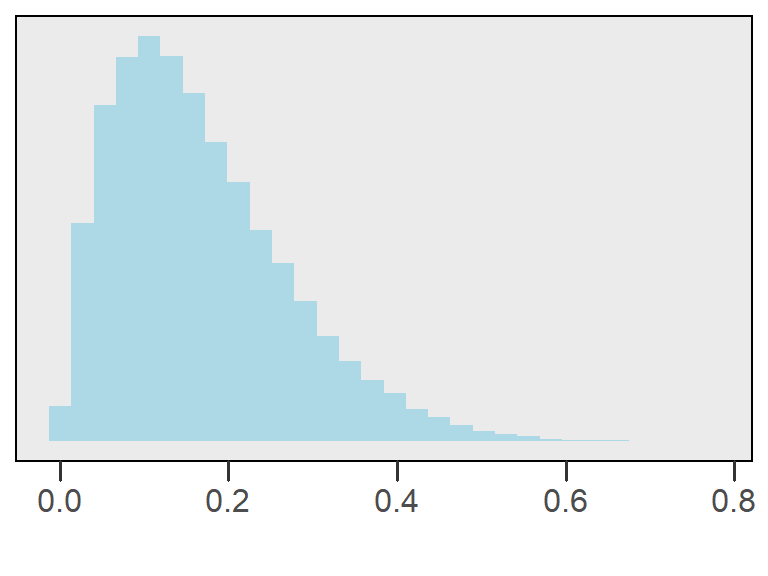

**(b)**

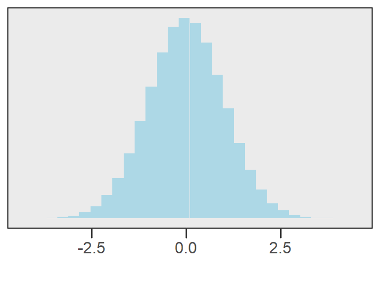

**(c)**

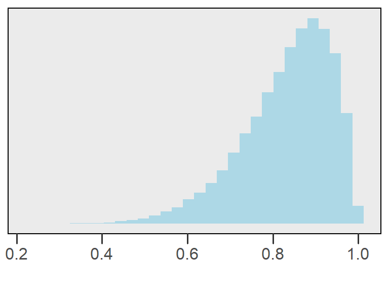

${\bf (13)}$ Consider the following four sets of observations of a quantitative variable $x$. For your convenience the observations have been sorted in increasing order. Match datasets $1-4$ with the correct histogram (labeled $A - D$)

$$\text{Dataset 1} = \{0.1, 1.1, 2.6, 2.7,
3.4, 3.4, 4.1, 4.4, 8.8, 9.6\}$$
$$\text{Dataset 2}= \{0.1, 0.3, 1.2, 2.4, 4.4, 4.5,
8.0, 8.9, 9.3, 9.3\}$$
$$\text{Dataset
3} = \{1.1, 3.8, 5.3, 6.0, 6.2, 6.9, 7.9, 7.9, 8.1, 8.7\}$$
$$\text{Dataset 4} = \{3.4, 4.5, 5.4, 5.6, 7.0,
8.5, 8.9, 9.2, 9.7, 9.7\}$$

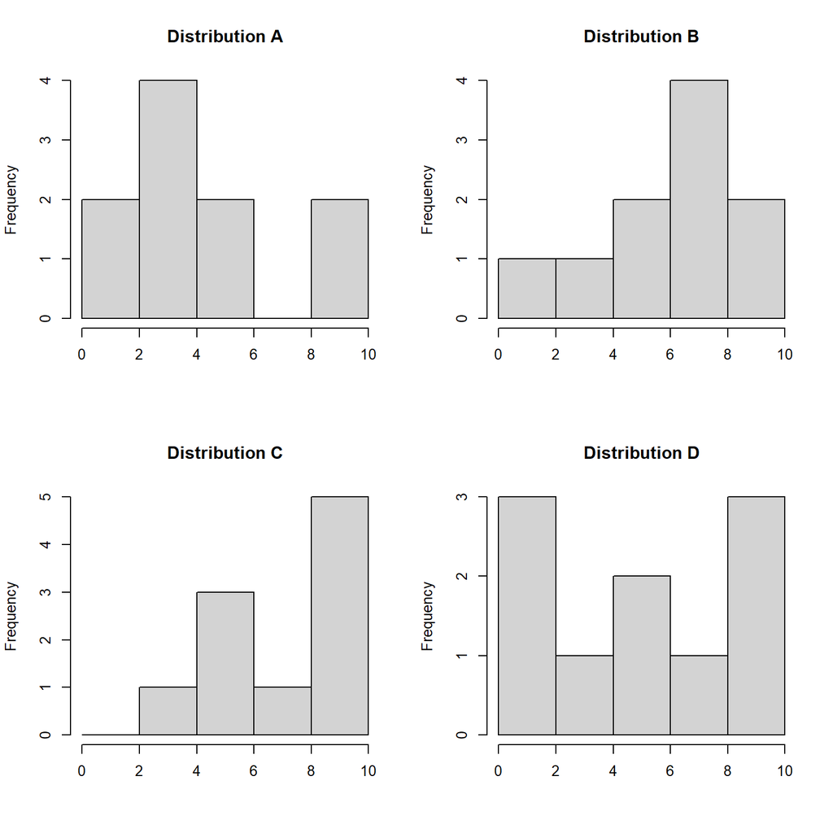

${\bf (14)}$ Consider the following set of 10 observations of a variable $X$ sorted from least to greatest:
$$3.3, 3.8, 4.0, 4.8, 4.8, 5.1, 5.2, 5.6, 5.7,
6.9$$
Use the data to answer parts a-b

- **(a)** Given the data, compute the $40^{th}$ percentile of $X$
- **(b)** Compute Interquartile Range (IQR) range of $X$

${\bf (15)}$ Consider the following $n = 20$ observations of several popular cereal brands and answer questions a - g about the variable “Sugar (g)”:

| Brand | Sodium (mg) | Sugar (g) | Type |
| --- | --- | --- | --- |
| Frosted Mini Wheats | 0 | 11 | A |
| Raisin Bran | 340 | 18 | A |
| All Bran | 70 | 5 | A |
| Apple Jacks | 140 | 14 | C |
| Captain Crunch | 200 | 12 | C |
| Cheerios | 180 | 1 | C |
| Cinnamon Toast Crunch | 210 | 10 | C |
| Crackling Oat Bran | 150 | 16 | A |
| Fiber One | 100 | 0 | A |
| Frosted Flakes | 130 | 12 | C |
| Froot Loops | 140 | 14 | C |
| Honey Bunches of Oats | 180 | 7 | A |
| Honey Nut Cheerios | 190 | 9 | C |
| Life | 160 | 6 | C |
| Rice Krispies | 290 | 3 | C |
| Honey Smacks | 50 | 15 | A |
| Special K | 220 | 4 | A |
| Wheaties | 180 | 4 | A |
| Corn Flakes | 200 | 3 | A |
| Honeycomb | 210 | 11 | C |

- **(a)** Construct a histogram of the data using the following bins: $\leq 2 (g)$, $2 - 4 (g)$, $4 - 6 (g)$, $6 - 8 (g)$,$8 - 10 (g)$, $10 - 12 (g)$, $12 - 14 (g)$,$14 - 16 (g)$,$> 16 (g)$ (hint start by creating a frequency table)
- **(b)** Compute the mean, median, and mode of the variable “Sugar (g)”
- **(c)** Compute the variance and standard deviation of the variable “Sugar (g)”
- **(d)** Compute the quartiles (Q1, Q2, Q3) and interquartile range of the variable “Sugar (g)”
- **(e)** Create a box and whisker plot for the variable “Sugar (g)” and mark the Q1, Q2, and Q3 quartiles, the median and any potential outliers
- **(f)** Plot the Cumulative Distribution of the variable “Sugar (g)”
- **(g)** What proportion of cereals have a sugar content less than or equal to 10 grams?